# Projeto - Red Wine

Pablo Gilvan Borges - pablogilvan@gmail.com

5/30/2018

```r
library(tidyverse)
library(gridExtra)
library(readr)
```

### Carregando os dados

```r
wines <- read.csv('wineQualityReds.csv')
```

### Listando uma amostra dos dados

```r
head(wines)
```

```
##   X fixed.acidity volatile.acidity citric.acid residual.sugar chlorides
## 1 1           7.4             0.70        0.00            1.9     0.076
## 2 2           7.8             0.88        0.00            2.6     0.098
## 3 3           7.8             0.76        0.04            2.3     0.092
## 4 4          11.2             0.28        0.56            1.9     0.075
## 5 5           7.4             0.70        0.00            1.9     0.076
## 6 6           7.4             0.66        0.00            1.8     0.075
##   free.sulfur.dioxide total.sulfur.dioxide density   pH sulphates alcohol
## 1                  11                   34  0.9978 3.51      0.56     9.4
## 2                  25                   67  0.9968 3.20      0.68     9.8
## 3                  15                   54  0.9970 3.26      0.65     9.8
## 4                  17                   60  0.9980 3.16      0.58     9.8
## 5                  11                   34  0.9978 3.51      0.56     9.4
## 6                  13                   40  0.9978 3.51      0.56     9.4
##   quality
## 1       5
## 2       5
## 3       5
## 4       6
## 5       5
## 6       5
```

#### Listando a quantidade de vinhos pela nota recebida

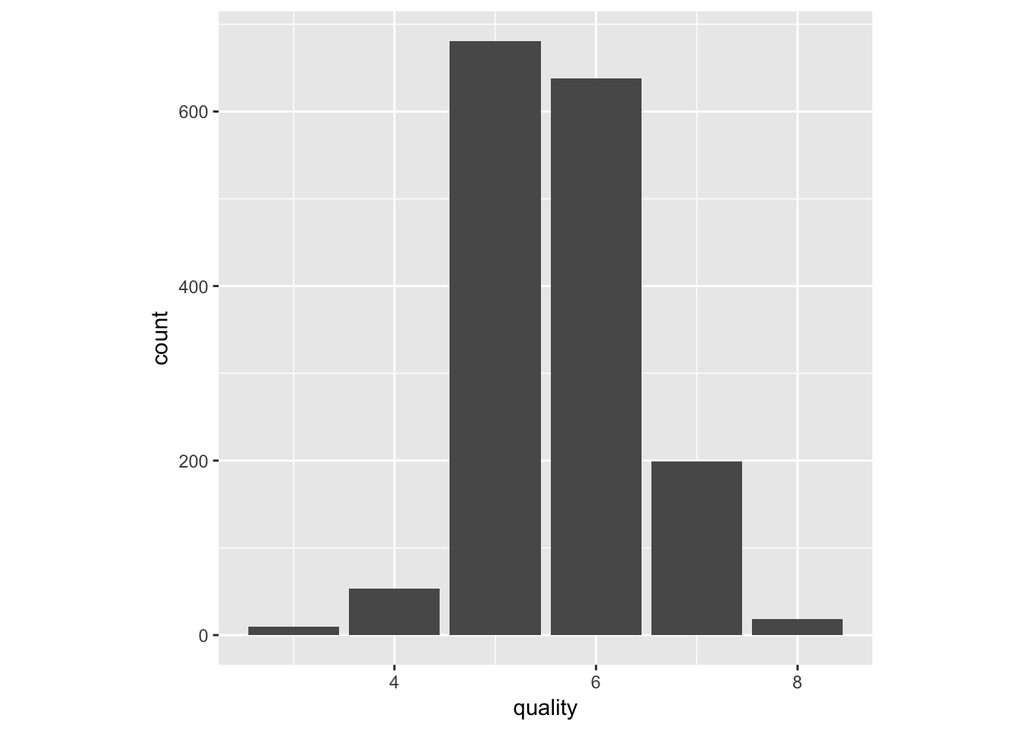

```r
ggplot(data = wines, mapping = aes(x = quality))+
  geom_bar()+theme(aspect.ratio = 1)
```

Ok, podemos ver que vinhos com notas 5 e 6 s??o a grande maioria. Mas qual a real propor????o da quantidade para cada nota.

```r
# Como vou querer usar boxplot, preciso converter a coluna Quality para o tipo 'factory'.
wines$quality <- factor(wines$quality)

#Vamos criar um novo conjunto de dados, onde vamos agrupar a quantidade de vinhos por qualidade
quality_summary <- wines %>% count(quality)
quality_summary
```

```
## # A tibble: 6 x 2
##   quality     n
##   <fctr>  <int>
## 1 3          10
## 2 4          53
## 3 5         681
## 4 6         638
## 5 7         199
## 6 8          18
```

```r
# Ok, podemos perceber que os vinhos com qualidades 5 e 6 compoeem mais de 80% da nossa amostra. Vamos mostrar isso de forma proporcional.

# Vamos dividir a quantidade de items de uma nota pela quantidade geral, assim teremos a propor????o de items para cada nota.
quality_summary <- quality_summary %>%
  mutate(prop_items = 100 * (n/sum(n)))

quality_summary
```

```
## # A tibble: 6 x 3
##   quality     n prop_items
##   <fctr>  <int>      <dbl>
## 1 3          10      0.625
## 2 4          53      3.31
## 3 5         681     42.6
## 4 6         638     39.9
## 5 7         199     12.4
## 6 8          18      1.13
```

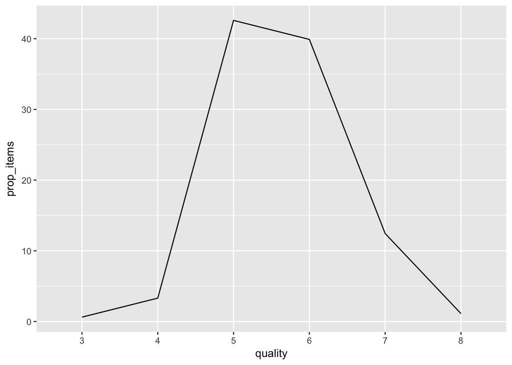

```r
# Como j?? antecipado, a soma de vinhos de qualidade 5 e 6 chega a mais de 80%. Vinhos com qualidade inferior a 4 est??o em menor quantidade que vinhos de qualidade 8, que tamb??m possuem uma contagem bem baixa: 1.1% do total de vinhos.

ggplot(data = quality_summary, mapping = aes(x = quality, y = prop_items, group = 1))+
  geom_line()
```

Em minhas buscas sobre o que compoem um bom vinho, achei um artigo(2) que indica uma rela????o entre o n??vel de alcool e a do??ura do mesmo, mas isso n??o ?? um indicador de que o vinho ?? bom por ser doce, muitas pessoas podem pensar exatamente o oposto, tendem a n??o gostar de vinhos mais adocicados. O artigo constata que vinhos com um percentual de 13% s??o mais adocicados e alega que n??o possuem a??ucares residuais, vamos cruzar os dados de vinhos com um percentual de alcool de 13% ou mais com a quantidade de a??ucar redisual.

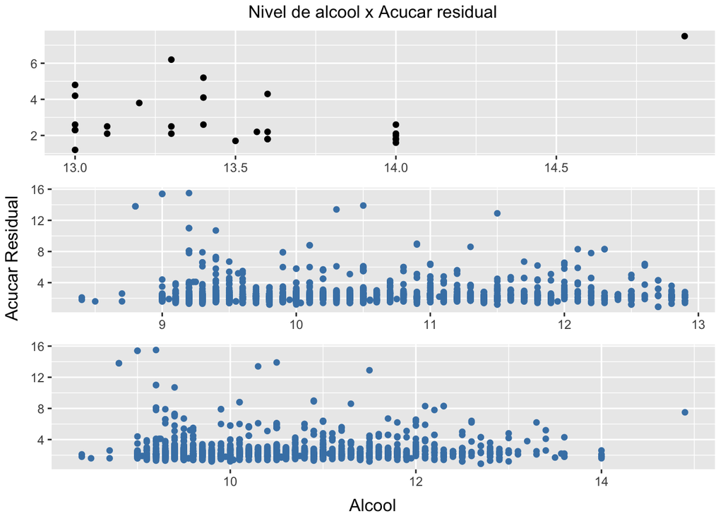

```r
g1 <- ggplot(data = filter(wines, wines$alcohol >= 13), mapping = aes(x = alcohol, y = residual.sugar))+
        geom_point()+labs(x = NULL, y = NULL)

g2 <- ggplot(data = filter(wines, wines$alcohol < 13), mapping = aes(x = alcohol, y = residual.sugar))+
        geom_point( color="steelblue")+labs(x = NULL, y = NULL)

g3 <- ggplot(data = wines, mapping = aes(x = alcohol, y = residual.sugar))+
        geom_point( color="steelblue")+labs(x = NULL, y = NULL)

grid.arrange(arrangeGrob(g1, g2, g3,
                         top = "Nivel de alcool x Acucar residual",
                         left = "Acucar Residual",
                         bottom = "Alcool"), nrow=1)
```